# Overview

#### Common Values

| Value | Count | Frequency (%) |
| --- | --- | --- |
| Braund, Mr. Owen Harris | 1 | 0.1% |
| Boulos, Mr. Hanna | 1 | 0.1% |
| Frolicher-Stehli, Mr. Maxmillian | 1 | 0.1% |
| Gilinski, Mr. Eliezer | 1 | 0.1% |
| Murdlin, Mr. Joseph | 1 | 0.1% |
| Rintamaki, Mr. Matti | 1 | 0.1% |
| Stephenson, Mrs. Walter Bertram (Martha Eustis) | 1 | 0.1% |
| Elsbury, Mr. William James | 1 | 0.1% |
| Bourke, Miss. Mary | 1 | 0.1% |
| Chapman, Mr. John Henry | 1 | 0.1% |
| Other values (881) | 881 | 98.9% |

#### Length

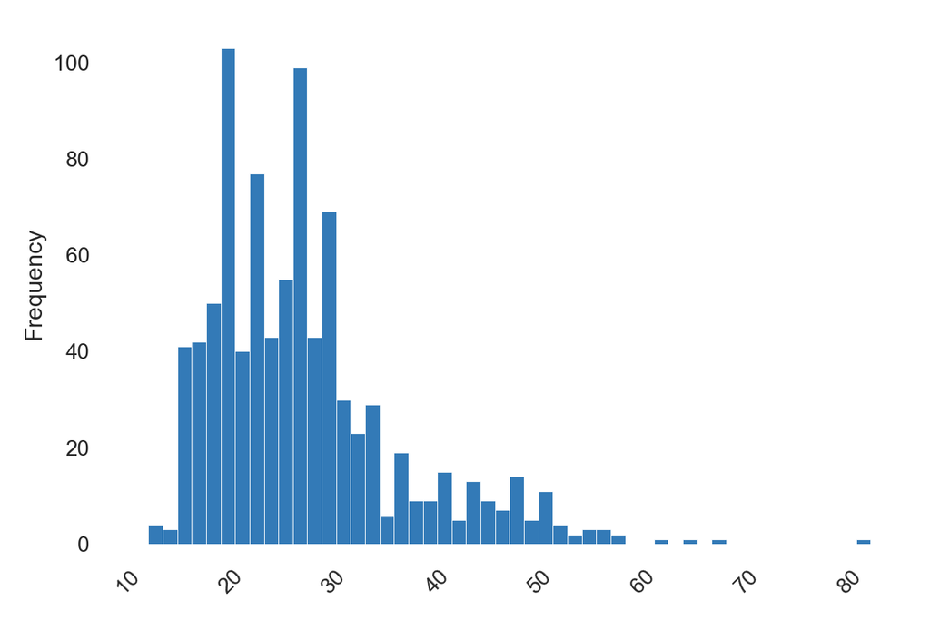

Histogram of lengths of the category

**Words**

| Value | Count | Frequency (%) |
| --- | --- | --- |
| mr | 521 | 14.4% |
| miss | 182 | 5.0% |
| mrs | 129 | 3.6% |
| william | 64 | 1.8% |
| john | 44 | 1.2% |
| master | 40 | 1.1% |
| henry | 35 | 1.0% |
| george | 24 | 0.7% |
| james | 24 | 0.7% |
| charles | 23 | 0.6% |
| Other values (1515) | 2538 | 70.0% |

**Characters**

**Characters**

#### Most occurring characters

| Value | Count | Frequency (%) |
| --- | --- | --- |
|  | 2735 | 11.4% |
| r | 1958 | 8.1% |
| e | 1703 | 7.1% |
| a | 1657 | 6.9% |
| i | 1325 | 5.5% |
| n | 1304 | 5.4% |
| s | 1297 | 5.4% |
| M | 1128 | 4.7% |
| l | 1067 | 4.4% |
| o | 1008 | 4.2% |
| Other values (50) | 8844 | 36.8% |

**Categories**

#### Most occurring categories

| Value | Count | Frequency (%) |
| --- | --- | --- |
| Lowercase Letter | 15446 | 64.3% |
| Uppercase Letter | 3645 | 15.2% |
| Space Separator | 2735 | 11.4% |
| Other Punctuation | 1899 | 7.9% |
| Close Punctuation | 144 | 0.6% |
| Open Punctuation | 144 | 0.6% |
| Dash Punctuation | 13 | 0.1% |

#### Most frequent character per category

##### *Lowercase Letter*

| Value | Count | Frequency (%) |
| --- | --- | --- |
| r | 1958 | 12.7% |
| e | 1703 | 11.0% |
| a | 1657 | 10.7% |
| i | 1325 | 8.6% |
| n | 1304 | 8.4% |
| s | 1297 | 8.4% |
| l | 1067 | 6.9% |
| o | 1008 | 6.5% |
| t | 667 | 4.3% |
| h | 517 | 3.3% |
| Other values (16) | 2943 | 19.1% |

##### *Uppercase Letter*

| Value | Count | Frequency (%) |
| --- | --- | --- |
| M | 1128 | 30.9% |
| A | 250 | 6.9% |
| J | 215 | 5.9% |
| H | 203 | 5.6% |
| S | 180 | 4.9% |
| C | 172 | 4.7% |
| E | 166 | 4.6% |
| W | 143 | 3.9% |
| B | 140 | 3.8% |
| L | 129 | 3.5% |
| Other values (15) | 919 | 25.2% |

##### *Other Punctuation*

| Value | Count | Frequency (%) |
| --- | --- | --- |
| . | 892 | 47.0% |
| , | 891 | 46.9% |
| " | 106 | 5.6% |
| ' | 9 | 0.5% |
| / | 1 | 0.1% |

##### *Space Separator*

| Value | Count | Frequency (%) |
| --- | --- | --- |
|  | 2735 | 100.0% |

##### *Close Punctuation*

| Value | Count | Frequency (%) |
| --- | --- | --- |
| ) | 144 | 100.0% |

##### *Open Punctuation*

| Value | Count | Frequency (%) |
| --- | --- | --- |
| ( | 144 | 100.0% |

##### *Dash Punctuation*

| Value | Count | Frequency (%) |
| --- | --- | --- |
| - | 13 | 100.0% |

**Scripts**

#### Most occurring scripts

| Value | Count | Frequency (%) |
| --- | --- | --- |
| Latin | 19091 | 79.5% |
| Common | 4935 | 20.5% |

#### Most frequent character per script

##### *Latin*

| Value | Count | Frequency (%) |
| --- | --- | --- |
| r | 1958 | 10.3% |
| e | 1703 | 8.9% |
| a | 1657 | 8.7% |
| i | 1325 | 6.9% |
| n | 1304 | 6.8% |
| s | 1297 | 6.8% |
| M | 1128 | 5.9% |
| l | 1067 | 5.6% |
| o | 1008 | 5.3% |
| t | 667 | 3.5% |
| Other values (41) | 5977 | 31.3% |

##### *Common*

| Value | Count | Frequency (%) |
| --- | --- | --- |
|  | 2735 | 55.4% |
| . | 892 | 18.1% |
| , | 891 | 18.1% |
| ) | 144 | 2.9% |
| ( | 144 | 2.9% |
| " | 106 | 2.1% |
| - | 13 | 0.3% |
| ' | 9 | 0.2% |
| / | 1 | < 0.1% |

**Blocks**

#### Most occurring blocks

| Value | Count | Frequency (%) |
| --- | --- | --- |
| ASCII | 24026 | 100.0% |

#### Most frequent character per block

##### *ASCII*

| Value | Count | Frequency (%) |
| --- | --- | --- |
|  | 2735 | 11.4% |
| r | 1958 | 8.1% |
| e | 1703 | 7.1% |
| a | 1657 | 6.9% |
| i | 1325 | 5.5% |
| n | 1304 | 5.4% |
| s | 1297 | 5.4% |
| M | 1128 | 4.7% |
| l | 1067 | 4.4% |
| o | 1008 | 4.2% |
| Other values (50) | 8844 | 36.8% |

Sex  
Categorical

`HIGH CORRELATION`

| Distinct | 2 |
| --- | --- |
| Distinct (%) | 0.2% |
| Missing | 0 |
| Missing (%) | 0.0% |
| Memory size | 53.8 KiB |

| male | 577 |
| --- | --- |
| female | 314 |

**Overview**

Length

| Max length | 6 |
| --- | --- |
| Median length | 4 |
| Mean length | 4.704826038 |
| Min length | 4 |

Characters and Unicode

| Total characters | 4192 |
| --- | --- |
| Distinct characters | 5 |
| Distinct categories | 1 [?](https://en.wikipedia.org/wiki/Unicode_character_property#General_Category) |
| Distinct scripts | 1 ? |
| Distinct blocks | 1 [?](https://en.wikipedia.org/wiki/Unicode_block) |

The Unicode Standard assigns character properties to each code point, which can be used to analyse textual variables.

Unique

| Unique | 0 ? |
| --- | --- |
| Unique (%) | 0.0% |

Sample

| 1st row | male |
| --- | --- |
| 2nd row | female |
| 3rd row | female |
| 4th row | female |
| 5th row | male |

**Categories**

#### Common Values

| Value | Count | Frequency (%) |
| --- | --- | --- |
| male | 577 | 64.8% |
| female | 314 | 35.2% |

#### Length

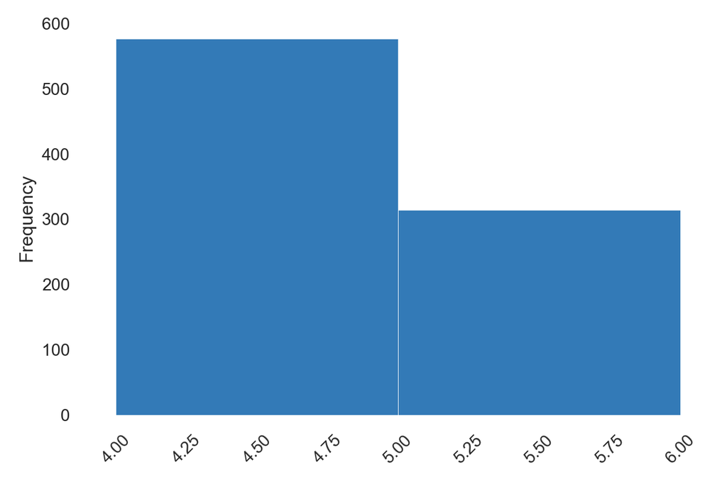

Histogram of lengths of the category

#### Category Frequency Plot

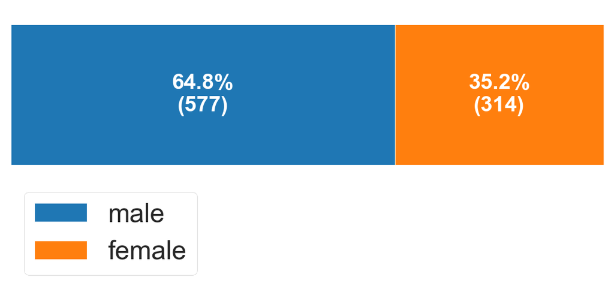

**Words**

| Value | Count | Frequency (%) |
| --- | --- | --- |
| male | 577 | 64.8% |
| female | 314 | 35.2% |

**Characters**

**Characters**

#### Most occurring characters

| Value | Count | Frequency (%) |
| --- | --- | --- |
| e | 1205 | 28.7% |
| m | 891 | 21.3% |
| a | 891 | 21.3% |
| l | 891 | 21.3% |
| f | 314 | 7.5% |

**Categories**

#### Most occurring categories

| Value | Count | Frequency (%) |
| --- | --- | --- |
| Lowercase Letter | 4192 | 100.0% |

#### Most frequent character per category

##### *Lowercase Letter*

| Value | Count | Frequency (%) |
| --- | --- | --- |
| e | 1205 | 28.7% |
| m | 891 | 21.3% |
| a | 891 | 21.3% |
| l | 891 | 21.3% |
| f | 314 | 7.5% |

**Scripts**

#### Most occurring scripts

| Value | Count | Frequency (%) |
| --- | --- | --- |
| Latin | 4192 | 100.0% |

#### Most frequent character per script

##### *Latin*

| Value | Count | Frequency (%) |
| --- | --- | --- |
| e | 1205 | 28.7% |
| m | 891 | 21.3% |
| a | 891 | 21.3% |
| l | 891 | 21.3% |
| f | 314 | 7.5% |

**Blocks**

#### Most occurring blocks

| Value | Count | Frequency (%) |
| --- | --- | --- |
| ASCII | 4192 | 100.0% |

#### Most frequent character per block

##### *ASCII*

| Value | Count | Frequency (%) |
| --- | --- | --- |
| e | 1205 | 28.7% |
| m | 891 | 21.3% |
| a | 891 | 21.3% |
| l | 891 | 21.3% |
| f | 314 | 7.5% |

Age  
Real number (ℝ<sub>≥0</sub>)

`MISSING`

| Distinct | 88 |
| --- | --- |
| Distinct (%) | 12.3% |
| Missing | 177 |
| Missing (%) | 19.9% |
| Infinite | 0 |
| Infinite (%) | 0.0% |
| Mean | 29.69911765 |

| Minimum | 0.42 |
| --- | --- |
| Maximum | 80 |
| Zeros | 0 |
| Zeros (%) | 0.0% |
| Negative | 0 |
| Negative (%) | 0.0% |
| Memory size | 7.1 KiB |

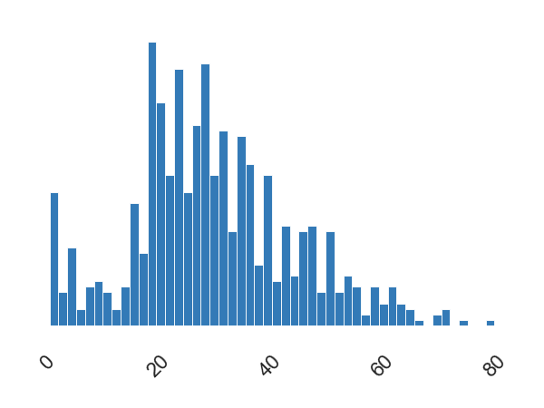

**Statistics**

Quantile statistics

| Minimum | 0.42 |
| --- | --- |
| 5-th percentile | 4 |
| Q1 | 20.125 |
| median | 28 |
| Q3 | 38 |
| 95-th percentile | 56 |
| Maximum | 80 |
| Range | 79.58 |
| Interquartile range (IQR) | 17.875 |

Descriptive statistics

| Standard deviation | 14.52649733 |
| --- | --- |
| Coefficient of variation (CV) | 0.4891221855 |
| Kurtosis | 0.1782741536 |
| Mean | 29.69911765 |
| Median Absolute Deviation (MAD) | 9 |
| Skewness | 0.3891077823 |
| Sum | 21205.17 |
| Variance | 211.0191247 |
| Monotonicity | Not monotonic |

**Histogram**

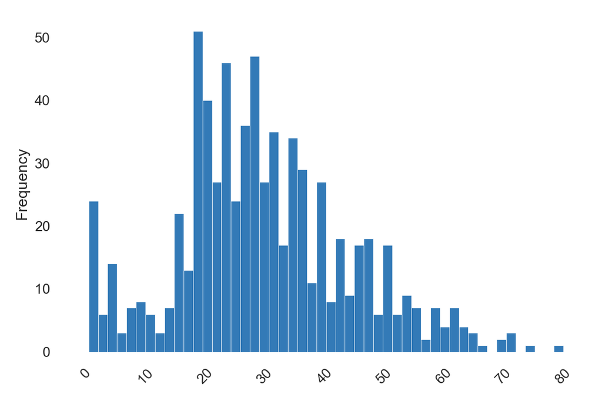

**Histogram with fixed size bins** (bins=50)

**Common values**

| Value | Count | Frequency (%) |
| --- | --- | --- |
| 24 | 30 | 3.4% |
| 22 | 27 | 3.0% |
| 18 | 26 | 2.9% |
| 28 | 25 | 2.8% |
| 30 | 25 | 2.8% |
| 19 | 25 | 2.8% |
| 21 | 24 | 2.7% |
| 25 | 23 | 2.6% |
| 36 | 22 | 2.5% |
| 29 | 20 | 2.2% |
| Other values (78) | 467 | 52.4% |
| (Missing) | 177 | 19.9% |

**Extreme values**

**Minimum 10 values**

| Value | Count | Frequency (%) |
| --- | --- | --- |
| 0.42 | 1 | 0.1% |
| 0.67 | 1 | 0.1% |
| 0.75 | 2 | 0.2% |
| 0.83 | 2 | 0.2% |
| 0.92 | 1 | 0.1% |
| 1 | 7 | 0.8% |
| 2 | 10 | 1.1% |
| 3 | 6 | 0.7% |
| 4 | 10 | 1.1% |
| 5 | 4 | 0.4% |

**Maximum 10 values**

| Value | Count | Frequency (%) |
| --- | --- | --- |
| 80 | 1 | 0.1% |
| 74 | 1 | 0.1% |
| 71 | 2 | 0.2% |
| 70.5 | 1 | 0.1% |
| 70 | 2 | 0.2% |
| 66 | 1 | 0.1% |
| 65 | 3 | 0.3% |
| 64 | 2 | 0.2% |
| 63 | 2 | 0.2% |
| 62 | 4 | 0.4% |

SibSp  
Real number (ℝ<sub>≥0</sub>)

`HIGH CORRELATION`  
`ZEROS`

| Distinct | 7 |
| --- | --- |
| Distinct (%) | 0.8% |
| Missing | 0 |
| Missing (%) | 0.0% |
| Infinite | 0 |
| Infinite (%) | 0.0% |
| Mean | 0.5230078563 |

| Minimum | 0 |
| --- | --- |
| Maximum | 8 |
| Zeros | 608 |
| Zeros (%) | 68.2% |
| Negative | 0 |
| Negative (%) | 0.0% |
| Memory size | 7.1 KiB |

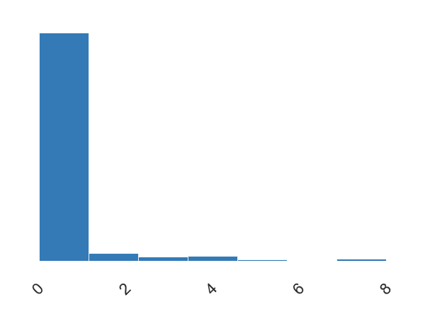

**Statistics**

Quantile statistics

| Minimum | 0 |
| --- | --- |
| 5-th percentile | 0 |
| Q1 | 0 |
| median | 0 |
| Q3 | 1 |
| 95-th percentile | 3 |
| Maximum | 8 |
| Range | 8 |
| Interquartile range (IQR) | 1 |

Descriptive statistics

| Standard deviation | 1.102743432 |
| --- | --- |
| Coefficient of variation (CV) | 2.108464374 |
| Kurtosis | 17.88041973 |
| Mean | 0.5230078563 |
| Median Absolute Deviation (MAD) | 0 |
| Skewness | 3.695351727 |
| Sum | 466 |
| Variance | 1.216043077 |
| Monotonicity | Not monotonic |

**Histogram**

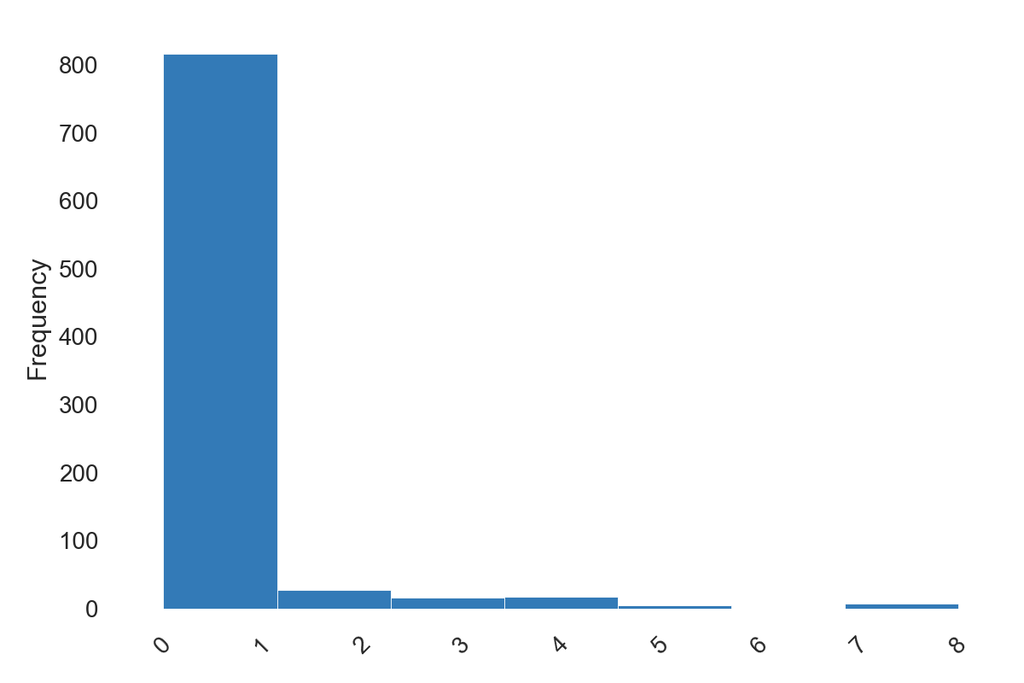

**Histogram with fixed size bins** (bins=7)

**Common values**

| Value | Count | Frequency (%) |
| --- | --- | --- |
| 0 | 608 | 68.2% |
| 1 | 209 | 23.5% |
| 2 | 28 | 3.1% |
| 4 | 18 | 2.0% |
| 3 | 16 | 1.8% |
| 8 | 7 | 0.8% |
| 5 | 5 | 0.6% |

**Extreme values**

**Minimum 10 values**

| Value | Count | Frequency (%) |
| --- | --- | --- |
| 0 | 608 | 68.2% |
| 1 | 209 | 23.5% |
| 2 | 28 | 3.1% |
| 3 | 16 | 1.8% |
| 4 | 18 | 2.0% |
| 5 | 5 | 0.6% |
| 8 | 7 | 0.8% |

**Maximum 10 values**

| Value | Count | Frequency (%) |
| --- | --- | --- |
| 8 | 7 | 0.8% |
| 5 | 5 | 0.6% |
| 4 | 18 | 2.0% |
| 3 | 16 | 1.8% |
| 2 | 28 | 3.1% |
| 1 | 209 | 23.5% |
| 0 | 608 | 68.2% |

Parch  
Real number (ℝ<sub>≥0</sub>)

`HIGH CORRELATION`  
`ZEROS`

| Distinct | 7 |
| --- | --- |
| Distinct (%) | 0.8% |
| Missing | 0 |
| Missing (%) | 0.0% |
| Infinite | 0 |
| Infinite (%) | 0.0% |
| Mean | 0.3815937149 |

| Minimum | 0 |
| --- | --- |
| Maximum | 6 |
| Zeros | 678 |
| Zeros (%) | 76.1% |
| Negative | 0 |
| Negative (%) | 0.0% |
| Memory size | 7.1 KiB |

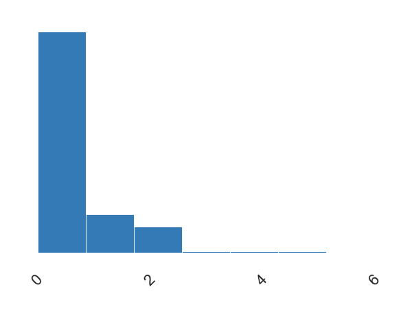

**Statistics**

Quantile statistics

| Minimum | 0 |
| --- | --- |
| 5-th percentile | 0 |
| Q1 | 0 |
| median | 0 |
| Q3 | 0 |
| 95-th percentile | 2 |
| Maximum | 6 |
| Range | 6 |
| Interquartile range (IQR) | 0 |

Descriptive statistics

| Standard deviation | 0.8060572211 |
| --- | --- |
| Coefficient of variation (CV) | 2.112344071 |
| Kurtosis | 9.778125179 |
| Mean | 0.3815937149 |
| Median Absolute Deviation (MAD) | 0 |
| Skewness | 2.749117047 |
| Sum | 340 |
| Variance | 0.6497282437 |
| Monotonicity | Not monotonic |

**Histogram**

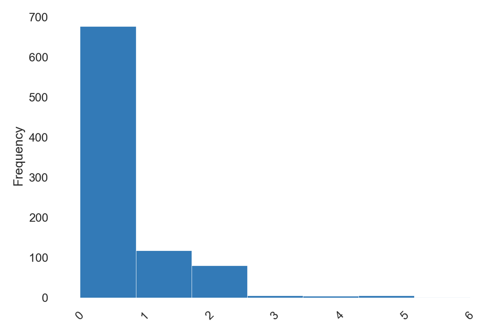

**Histogram with fixed size bins** (bins=7)

**Common values**

| Value | Count | Frequency (%) |
| --- | --- | --- |
| 0 | 678 | 76.1% |
| 1 | 118 | 13.2% |
| 2 | 80 | 9.0% |
| 5 | 5 | 0.6% |
| 3 | 5 | 0.6% |
| 4 | 4 | 0.4% |
| 6 | 1 | 0.1% |

**Extreme values**

**Minimum 10 values**

| Value | Count | Frequency (%) |
| --- | --- | --- |
| 0 | 678 | 76.1% |
| 1 | 118 | 13.2% |
| 2 | 80 | 9.0% |
| 3 | 5 | 0.6% |
| 4 | 4 | 0.4% |
| 5 | 5 | 0.6% |
| 6 | 1 | 0.1% |

**Maximum 10 values**

| Value | Count | Frequency (%) |
| --- | --- | --- |
| 6 | 1 | 0.1% |
| 5 | 5 | 0.6% |
| 4 | 4 | 0.4% |
| 3 | 5 | 0.6% |
| 2 | 80 | 9.0% |
| 1 | 118 | 13.2% |
| 0 | 678 | 76.1% |

Ticket  
Categorical

`HIGH CARDINALITY`  
`UNIFORM`

| Distinct | 681 |
| --- | --- |
| Distinct (%) | 76.4% |
| Missing | 0 |
| Missing (%) | 0.0% |
| Memory size | 55.6 KiB |

| 347082 | 7 |
| --- | --- |
| CA. 2343 | 7 |
| 1601 | 7 |
| 3101295 | 6 |
| CA 2144 | 6 |
| Other values (676) | 858 |

**Overview**

Length

[output not shown]

Characters and Unicode

| Total characters | 6015 |
| --- | --- |
| Distinct characters | 35 |
| Distinct categories | 5 [?](https://en.wikipedia.org/wiki/Unicode_character_property#General_Category) |
| Distinct scripts | 2 ? |
| Distinct blocks | 1 [?](https://en.wikipedia.org/wiki/Unicode_block) |

The Unicode Standard assigns character properties to each code point, which can be used to analyse textual variables.

Unique

| Unique | 547 ? |
| --- | --- |
| Unique (%) | 61.4% |

Sample

| 1st row | A/5 21171 |
| --- | --- |
| 2nd row | PC 17599 |
| 3rd row | STON/O2. 3101282 |
| 4th row | 113803 |
| 5th row | 373450 |

**Categories**

#### Common Values

| Value | Count | Frequency (%) |
| --- | --- | --- |
| 347082 | 7 | 0.8% |
| CA. 2343 | 7 | 0.8% |
| 1601 | 7 | 0.8% |
| 3101295 | 6 | 0.7% |
| CA 2144 | 6 | 0.7% |
| 347088 | 6 | 0.7% |
| S.O.C. 14879 | 5 | 0.6% |
| 382652 | 5 | 0.6% |
| LINE | 4 | 0.4% |
| PC 17757 | 4 | 0.4% |
| Other values (671) | 834 | 93.6% |

#### Length

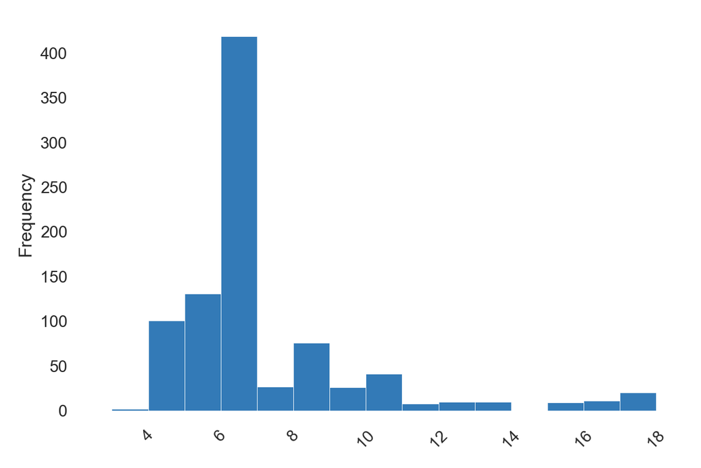

Histogram of lengths of the category

**Words**

| Value | Count | Frequency (%) |
| --- | --- | --- |
| pc | 60 | 5.3% |
| c.a | 27 | 2.4% |
| a/5 | 17 | 1.5% |
| ca | 14 | 1.2% |
| ston/o | 12 | 1.1% |
| 2 | 12 | 1.1% |
| sc/paris | 9 | 0.8% |
| w./c | 9 | 0.8% |
| soton/o.q | 8 | 0.7% |
| 347082 | 7 | 0.6% |
| Other values (709) | 955 | 84.5% |

**Characters**

**Characters**

#### Most occurring characters

| Value | Count | Frequency (%) |
| --- | --- | --- |
| 3 | 746 | 12.4% |
| 1 | 689 | 11.5% |
| 2 | 594 | 9.9% |
| 7 | 490 | 8.1% |
| 4 | 464 | 7.7% |
| 6 | 422 | 7.0% |
| 0 | 406 | 6.7% |
| 5 | 387 | 6.4% |
| 9 | 328 | 5.5% |
| 8 | 282 | 4.7% |
| Other values (25) | 1207 | 20.1% |

**Categories**

#### Most occurring categories

| Value | Count | Frequency (%) |
| --- | --- | --- |
| Decimal Number | 4808 | 79.9% |
| Uppercase Letter | 652 | 10.8% |
| Other Punctuation | 295 | 4.9% |
| Space Separator | 239 | 4.0% |
| Lowercase Letter | 21 | 0.3% |

#### Most frequent character per category

##### *Uppercase Letter*

| Value | Count | Frequency (%) |
| --- | --- | --- |
| C | 151 | 23.2% |
| O | 100 | 15.3% |
| P | 98 | 15.0% |
| A | 82 | 12.6% |
| S | 74 | 11.3% |
| N | 40 | 6.1% |
| T | 36 | 5.5% |
| W | 16 | 2.5% |
| Q | 15 | 2.3% |
| I | 11 | 1.7% |
| Other values (6) | 29 | 4.4% |

##### *Decimal Number*

| Value | Count | Frequency (%) |
| --- | --- | --- |
| 3 | 746 | 15.5% |
| 1 | 689 | 14.3% |
| 2 | 594 | 12.4% |
| 7 | 490 | 10.2% |
| 4 | 464 | 9.7% |
| 6 | 422 | 8.8% |
| 0 | 406 | 8.4% |
| 5 | 387 | 8.0% |
| 9 | 328 | 6.8% |
| 8 | 282 | 5.9% |

##### *Lowercase Letter*

| Value | Count | Frequency (%) |
| --- | --- | --- |
| a | 6 | 28.6% |
| s | 5 | 23.8% |
| r | 4 | 19.0% |
| i | 4 | 19.0% |
| l | 1 | 4.8% |
| e | 1 | 4.8% |

##### *Other Punctuation*

| Value | Count | Frequency (%) |
| --- | --- | --- |
| . | 197 | 66.8% |
| / | 98 | 33.2% |

##### *Space Separator*

| Value | Count | Frequency (%) |
| --- | --- | --- |
|  | 239 | 100.0% |

**Scripts**

#### Most occurring scripts

| Value | Count | Frequency (%) |
| --- | --- | --- |
| Common | 5342 | 88.8% |
| Latin | 673 | 11.2% |

#### Most frequent character per script

##### *Latin*

| Value | Count | Frequency (%) |
| --- | --- | --- |
| C | 151 | 22.4% |
| O | 100 | 14.9% |
| P | 98 | 14.6% |
| A | 82 | 12.2% |
| S | 74 | 11.0% |
| N | 40 | 5.9% |
| T | 36 | 5.3% |
| W | 16 | 2.4% |
| Q | 15 | 2.2% |
| I | 11 | 1.6% |
| Other values (12) | 50 | 7.4% |

##### *Common*

| Value | Count | Frequency (%) |
| --- | --- | --- |
| 3 | 746 | 14.0% |
| 1 | 689 | 12.9% |
| 2 | 594 | 11.1% |
| 7 | 490 | 9.2% |
| 4 | 464 | 8.7% |
| 6 | 422 | 7.9% |
| 0 | 406 | 7.6% |
| 5 | 387 | 7.2% |
| 9 | 328 | 6.1% |
| 8 | 282 | 5.3% |
| Other values (3) | 534 | 10.0% |

**Blocks**

#### Most occurring blocks

| Value | Count | Frequency (%) |
| --- | --- | --- |
| ASCII | 6015 | 100.0% |